# kaggle 인사 데이터를 통한 퇴사 예측 모델링

Sung

2017-12-16

## 데이터 소개

- 직원들이 퇴사 여부에 대한 대한 시뮬레이션 데이터
- 데이터 column 정보

  | column 명 | 의미 | 타입 정보 |
  | --- | --- | --- |
  | satisfaction_level | 만족도 | numeric(0~1) |
  | last_evaluation | 마지막 평가 | numeric(0~1) |
  | number_project | 완료한 프로젝트 수 | integer(1~10) |
  | average_montly_hours | 월평균 근무 시간 | numeric |
  | time_spend_company | 근속 년수 | integer(1~10) |
  | Work_accident | 업무상 과실 여부 | factor(0, 1) |
  | left | 퇴사 여부 | factor(0, 1) |
  | promotion_last_5years | 최근 5년 내 승진 여부 | factor(0, 1) |
  | sales | 부서 | string |
  | salary | 연봉수준 | string |

  - 출처: https://www.kaggle.com/ludobenistant/hr-analytics

## 데이터 불러오기

- 각 변수의 타입에 맞게 데이터 불러오기

  ```r
  # load package
  library(tidyverse)

  # column type: c = character, i = integer, n = number, d = double, l =logical, D = date, T = date time, t = time, ? = guess, or _/- to skip the column.
  hra_raw <- read_csv("../data/HR_comma_sep.csv",
                     col_types = cols(.default = "d",
                                      number_project = "i",
                                      time_spend_company = "i",
                                      Work_accident = col_factor(c(0, 1)),
                                      left = col_factor(c(0, 1)),
                                      promotion_last_5years = col_factor(c(0, 1)),
                                      sales = "c", salary = "c"))

  glimpse(hra_raw)
  ##> Observations: 14,999
  ##> Variables: 10
  ##> $ satisfaction_level    <dbl> 0.38, 0.80, 0.11, 0.72, 0.37, 0.41, 0.10...
  ##> $ last_evaluation       <dbl> 0.53, 0.86, 0.88, 0.87, 0.52, 0.50, 0.77...
  ##> $ number_project        <int> 2, 5, 7, 5, 2, 2, 6, 5, 5, 2, 2, 6, 4, 2...
  ##> $ average_montly_hours  <dbl> 157, 262, 272, 223, 159, 153, 247, 259, ...
  ##> $ time_spend_company    <int> 3, 6, 4, 5, 3, 3, 4, 5, 5, 3, 3, 4, 5, 3...
  ##> $ Work_accident         <fctr> 0, 0, 0, 0, 0, 0, 0, 0, 0, 0, 0, 0, 0, ...
  ##> $ left                  <fctr> 1, 1, 1, 1, 1, 1, 1, 1, 1, 1, 1, 1, 1, ...
  ##> $ promotion_last_5years <fctr> 0, 0, 0, 0, 0, 0, 0, 0, 0, 0, 0, 0, 0, ...
  ##> $ sales                 <chr> "sales", "sales", "sales", "sales", "sal...
  ##> $ salary                <chr> "low", "medium", "medium", "low", "low",...
  ```

## 탐색적 자료 분석(EDA)

- 변수별 데이터 확인
  - 전체 건수는 14999건임
  - 모든 변수에는 `NA` 값은 존재하지 않음

  ```r
  # load packages
  library(knitr)
  library(kableExtra)

  # na 건수 체크 및 출력
  hra_raw %>%
      summarise_all(funs(sum(is.na(.)))) %>%
      gather(var_name, na_cnt) %>%
      kable(format = "html") %>%
      kable_styling(bootstrap_options = "striped", full_width = F, position = "left")
  ```

  | var_name | na_cnt |
  | --- | --- |
  | satisfaction_level | 0 |
  | last_evaluation | 0 |
  | number_project | 0 |
  | average_montly_hours | 0 |
  | time_spend_company | 0 |
  | Work_accident | 0 |
  | left | 0 |
  | promotion_last_5years | 0 |
  | sales | 0 |
  | salary | 0 |

  ```r
  # ktable 참고: https://cran.r-project.org/web/packages/kableExtra/vignettes/awesome_table_in_html.html
  ```

- 변수별 상관 분석
  - 완료 프로젝트수와 월평균 근무시간과 마지막평가가 약한 양의 상관관계가 있음

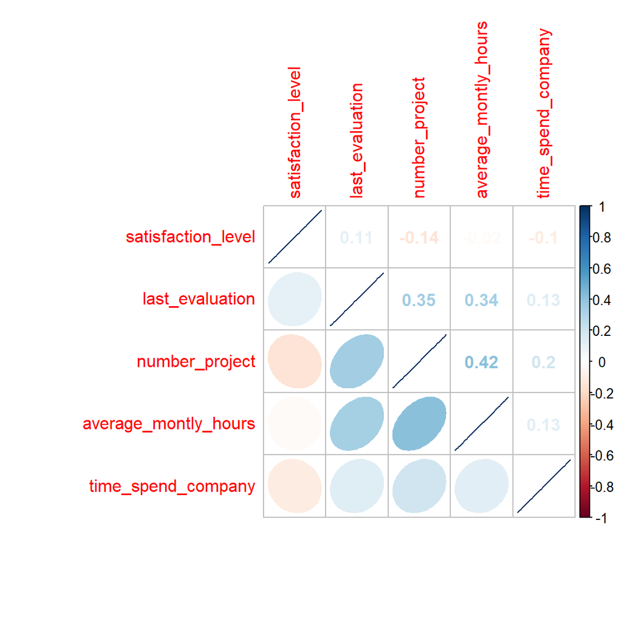

  ```r
  # 상관 분석
  library(corrplot)
  hra_raw %>%
      select_if(is.numeric) %>%
      cor() %>%
      corrplot.mixed(lower="ellipse", upper="number", tl.pos = c("lt"), diag = c("l"))
  ```

- 변수별 통계 및 시각화
  - 퇴사 여부 : 퇴사자 비율은 23.808%로 불균형 자료임

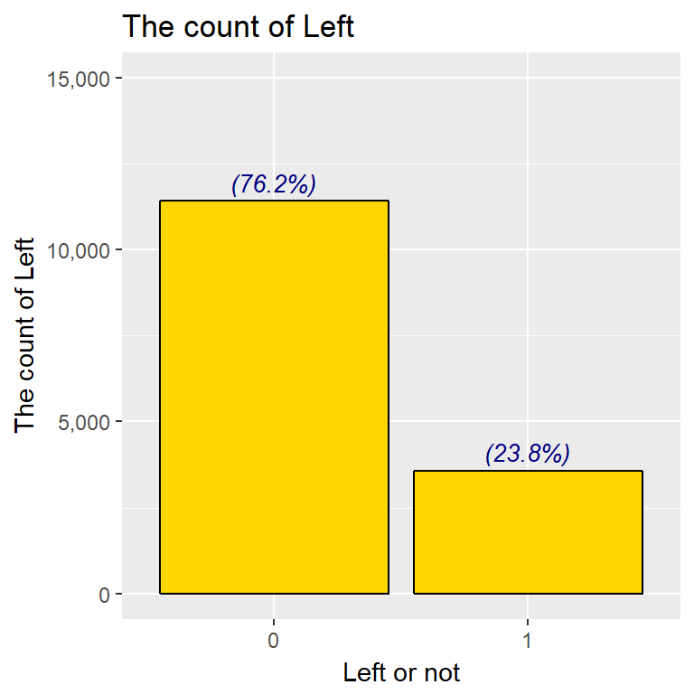

  ```r
  # load package
  library(scales)

  # 퇴사자 수 및 비율
  hra_raw %>%
      group_by(left) %>%
      summarise(left_cnt = n()) %>%
      mutate(left_rate = left_cnt / sum(left_cnt) * 100) %>%
      ggplot(aes(x = reorder(left, -left_cnt), y = left_cnt)) +
      geom_bar(stat = "identity", color = "black", fill="gold") +
      geom_text(aes(label = paste0("(", round(left_rate, 1), "%)")), size = 3.5, vjust = -0.5, color = 'navyblue', fontface = 'italic') +
      scale_y_continuous(labels = comma, limits = c(0, 15000)) +
      labs(x = "Left or not", y = "The count of Left", title = "The count of Left")
  ```

  - 마지막 평가

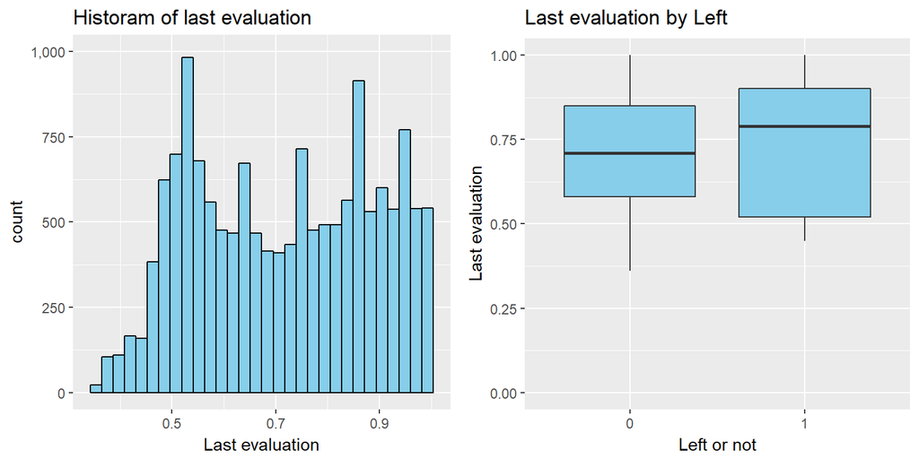

  ```r
  # grid package load
  library(gridExtra)

  # 마지막 평가 분포
  eval_plot <- hra_raw %>%
      ggplot(aes(last_evaluation)) +
      geom_histogram(bins = 30, color = "black", fill="skyblue") +
      scale_y_continuous(labels = comma, limits = c(0, 1000)) +
      labs(x = "Last evaluation", y = "count", title = "Historam of last evaluation")

  # 마지막 평가 * 퇴사여부
  eval_left_plot <- hra_raw %>%
      ggplot(aes(x = left, y = last_evaluation)) +
      geom_boxplot(fill = "skyblue") +
      scale_y_continuous(labels = comma, limits = c(0, 1)) +
      labs(x = "Left or not", y = "Last evaluation", title = "Last evaluation by Left")

  grid.arrange(eval_plot, eval_left_plot, ncol = 2)
  ```

  - 만족도

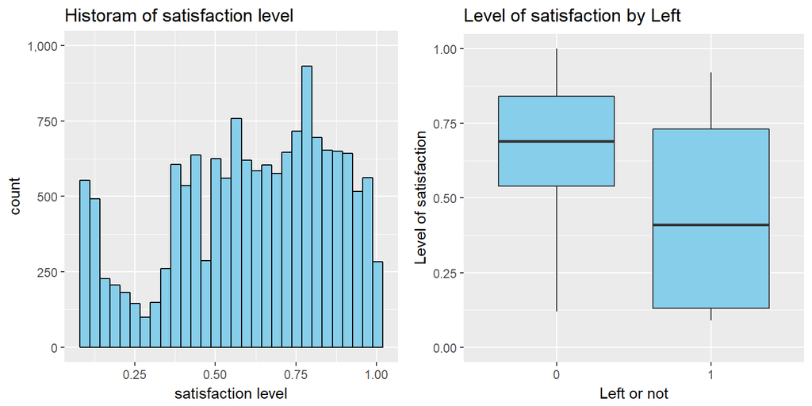

  ```r
  # grid package load
  library(gridExtra)

  # 만족도 분포
  satis_plot <- hra_raw %>%
      ggplot(aes(satisfaction_level)) +
      geom_histogram(bins = 30, color = "black", fill="skyblue") +
      scale_y_continuous(labels = comma, limits = c(0, 1000)) +
      labs(x = "satisfaction level", y = "count", title = "Historam of satisfaction level")

  # 만족도 * 퇴사여부
  satis_left_plot <- hra_raw %>%
      ggplot(aes(x = left, y = satisfaction_level)) +
      geom_boxplot(fill = "skyblue") +
      scale_y_continuous(labels = comma, limits = c(0, 1)) +
      labs(x = "Left or not", y = "Level of satisfaction", title = "Level of satisfaction by Left")

  grid.arrange(satis_plot, satis_left_plot, ncol = 2)
  ```

  - 월평균 근무시간

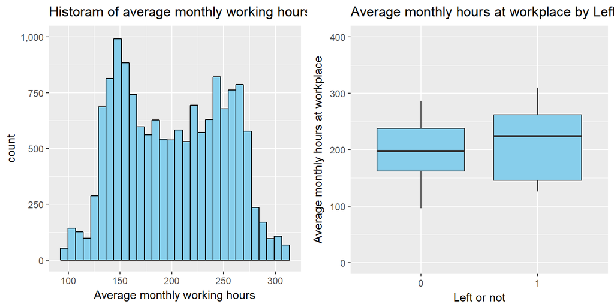

  ```r
  # grid package load
  library(gridExtra)

  # 월평균 근무 시간 분
  avg_working_hours_plot <- hra_raw %>%
      ggplot(aes(average_montly_hours)) +
      geom_histogram(bins = 30, color = "black", fill="skyblue") +
      scale_y_continuous(labels = comma, limits = c(0, 1000)) +
      labs(x = "Average monthly working hours", y = "count", title = "Historam of average monthly working hours")

  # 월평균 근무시간 * 퇴사여부
  avg_working_hours_left_plot <- hra_raw %>%
      ggplot(aes(x = left, y = average_montly_hours)) +
      geom_boxplot(fill = "skyblue") +
      scale_y_continuous(labels = comma, limits = c(0, 400)) +
      labs(x = "Left or not", y = "Average monthly hours at workplace", title = "Average monthly hours at workplace by Left")

  grid.arrange(avg_working_hours_plot, avg_working_hours_left_plot, ncol = 2)
  ```

  - 완료한 프로젝트수

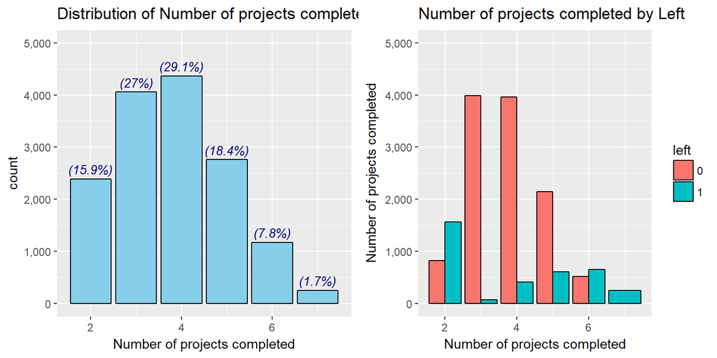

  ```r
  # grid package load
  library(gridExtra)

  # 완료한 프로젝트 수
  num_project_plot <- hra_raw %>%
      group_by(number_project) %>%
      summarise(cnt = n()) %>%
      mutate(number_project_rate = cnt / sum(cnt) * 100) %>%
      ggplot(aes(x = number_project, y = cnt)) +
      geom_bar(stat = "identity", color = "black", fill="skyblue") +
      geom_text(aes(label = paste0("(",round(number_project_rate, 1), "%)")), size = 3.5, vjust = -0.5, color = 'navyblue', fontface = 'italic') +
      scale_y_continuous(labels = comma, limits = c(0, 5000)) +
      labs(x = "Number of projects completed", y = "count", title = "Distribution of Number of projects completed")

  # 완료된 프로젝트 수 * 퇴사여부
  num_project_left_plot <- hra_raw %>%
      group_by(left, number_project) %>%
      summarise(left_cnt = n()) %>%
      ggplot(aes(x = number_project, y = left_cnt)) +
      geom_bar(stat = "identity", colour = "black", aes(fill = left), position="dodge") +
      scale_y_continuous(labels = comma, limits = c(0, 5000)) +
      labs(x = "Number of projects completed", y = "Number of projects completed", title = "Number of projects completed by Left")

  grid.arrange(num_project_plot, num_project_left_plot, ncol = 2)
  ```

  - 근속 년수

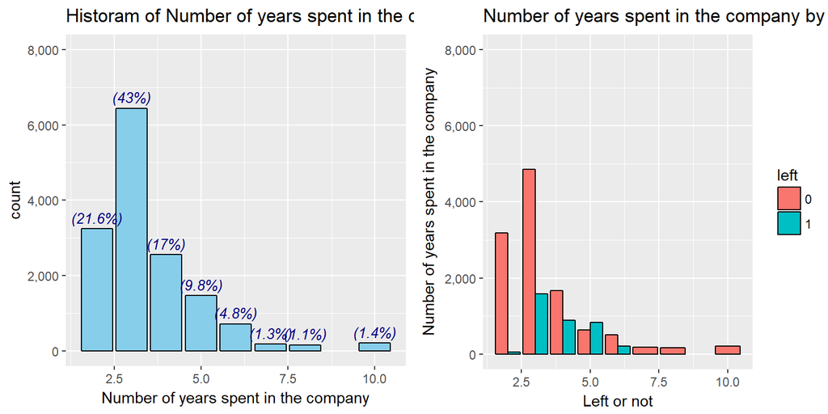

  ```r
  # 근속 년수 분포
  ts_company_plot <- hra_raw %>%
      group_by(time_spend_company) %>%
      summarise(cnt = n()) %>%
      mutate(time_spend_company_rate = cnt / sum(cnt) * 100) %>%
      ggplot(aes(x = time_spend_company, y = cnt)) +
      geom_bar(stat = "identity", color = "black", fill="skyblue") +
      geom_text(aes(label = paste0("(",round(time_spend_company_rate, 1), "%)")), size = 3.5, vjust = -0.5, color = 'navyblue', fontface = 'italic') +
      scale_y_continuous(labels = comma, limits = c(0, 8000)) +
      labs(x = "Number of years spent in the company", y = "count", title = "Historam of Number of years spent in the company")

  # 근속 년수 * 퇴사여부
  ts_company_left_plot <- hra_raw %>%
      group_by(left, time_spend_company) %>%
      summarise(left_cnt = n()) %>%
      ggplot(aes(x = time_spend_company, y = left_cnt)) +
      geom_bar(stat = "identity", colour = "black", aes(fill = left), position="dodge") +
      scale_y_continuous(labels = comma, limits = c(0, 8000)) +
      labs(x = "Left or not", y = "Number of years spent in the company", title = "Number of years spent in the company by Left")

  grid.arrange(ts_company_plot, ts_company_left_plot, ncol = 2)
  ```

  - 업무상 과실여부, 최근 5년내 승진여부

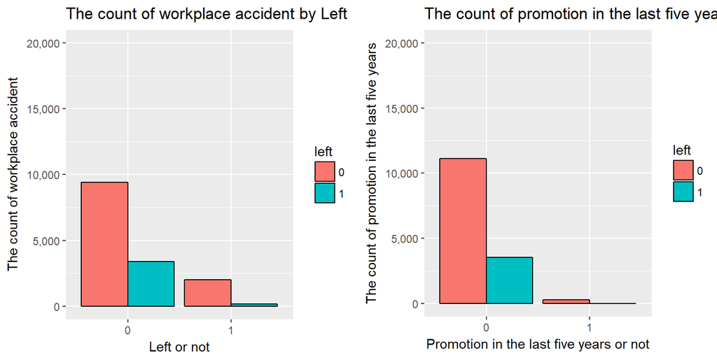

  ```r
  # 업무상 과실 여부 * 퇴사여부
  work_accident_left_plot <- hra_raw %>%
      group_by(left, Work_accident) %>%
      summarise(left_cnt = n()) %>%
      ggplot(aes(x = Work_accident, y = left_cnt)) +
      geom_bar(stat = "identity", colour = "black", aes(fill = left), position="dodge") +
      scale_y_continuous(labels = comma, limits = c(0, 20000)) +
      labs(x = "Left or not", y = "The count of workplace accident", title = "The count of workplace accident by Left")


  # 최근 5년 내 승진 여부 * 퇴사여부
  promotion_5y_left_plot <- hra_raw %>%
      group_by(left, promotion_last_5years) %>%
      summarise(left_cnt = n()) %>%
      ggplot(aes(x = promotion_last_5years, y = left_cnt)) +
      geom_bar(stat = "identity", colour = "black", aes(fill = left), position="dodge") +
      scale_y_continuous(labels = comma, limits = c(0, 20000)) +
      labs(x = "Promotion in the last five years or not", y = "The count of promotion in the last five years", title = "The count of promotion in the last five years by Left")

  grid.arrange(work_accident_left_plot, promotion_5y_left_plot, ncol = 2)
  ```

  - 부서, 연봉수준

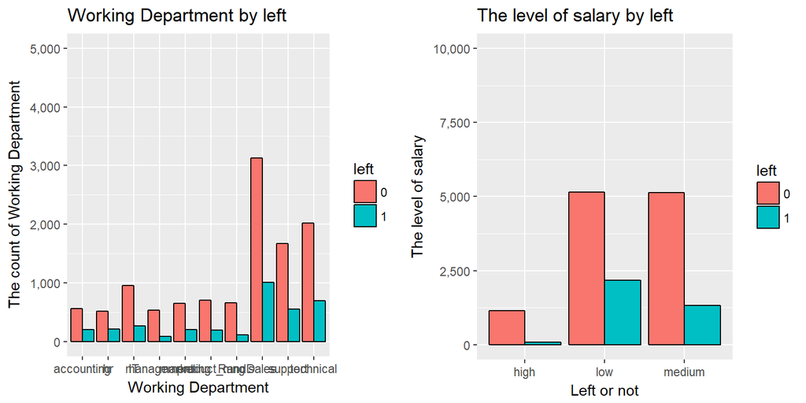

  ```r
  # 부서 * 퇴사여부
  department_left_plot <- hra_raw %>%
      group_by(left, sales) %>%
      summarise(left_cnt = n()) %>%
      ggplot(aes(x = sales, y = left_cnt)) +
      geom_bar(stat = "identity", colour = "black", aes(fill = left), position="dodge") +
      scale_y_continuous(labels = comma, limits = c(0, 5000)) +
      labs(x = "Working Department", y = "The count of Working Department", title = "Working Department by left")


  # 연봉 수준 * 퇴사여부
  salary_left_plot <- hra_raw %>%
      group_by(left, salary) %>%
      summarise(left_cnt = n()) %>%
      ggplot(aes(x = salary, y = left_cnt)) +
      geom_bar(stat = "identity", colour = "black", aes(fill = left), position="dodge") +
      scale_y_continuous(labels = comma, limits = c(0, 10000)) +
      labs(x = "Left or not", y = "The level of salary", title = "The level of salary by left")

  grid.arrange(department_left_plot, salary_left_plot, ncol = 2)
  ```

  - 퇴사자 중 만족도 * 마지막 평가 * 월평균 근무 시간

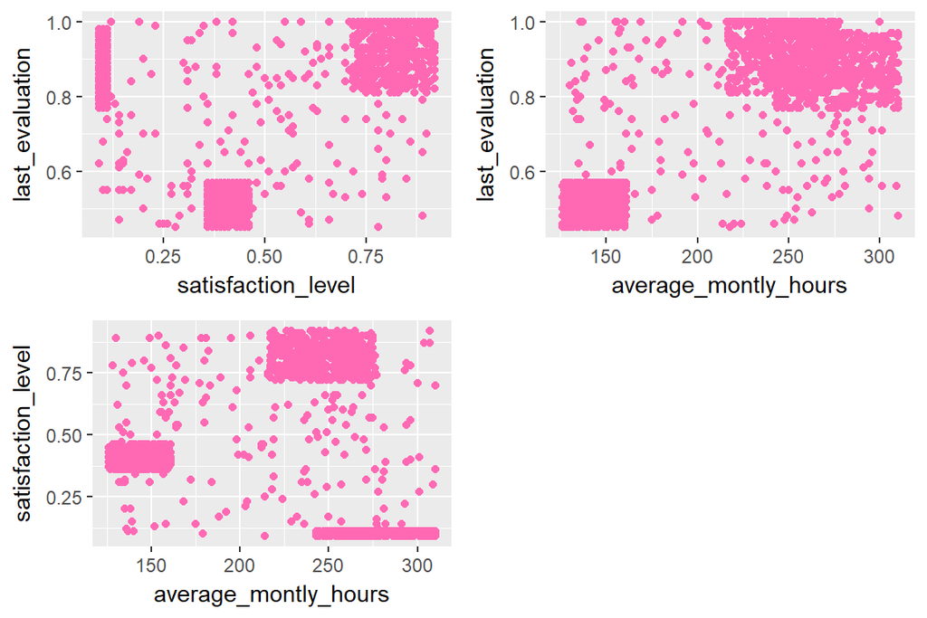

  ```r
  # 퇴사자 중 만족도 * 마지막 평가
  left_satis_eval_plot <- hra_raw %>%
      filter(left == 1) %>%
      ggplot(aes(x = satisfaction_level, y = last_evaluation)) +
      geom_point(color = "hotpink")

  # 퇴사자 중 월평균 근무 시간 * 마지막 평가
  left_avg_working_hours_eval_plot <- hra_raw %>%
      filter(left == 1) %>%
      ggplot(aes(x = average_montly_hours, y = last_evaluation)) +
      geom_point(color = "hotpink")

  # 퇴사자 중 월평균 근무 시간 * 만족도
  left_avg_working_hours_satis_plot <- hra_raw %>%
      filter(left == 1) %>%
      ggplot(aes(x = average_montly_hours, y = satisfaction_level)) +
      geom_point(color = "hotpink")

  grid.arrange(left_satis_eval_plot, left_avg_working_hours_eval_plot, left_avg_working_hours_satis_plot, ncol = 2)
  ```

  - 퇴사자 클러스터링
    - 사용 변수: 만족도, 마지막 평가, 월평균 근무시간
    - 군집 개수: 4개 (1. sum of square 사용, 2. NBClust 사용)

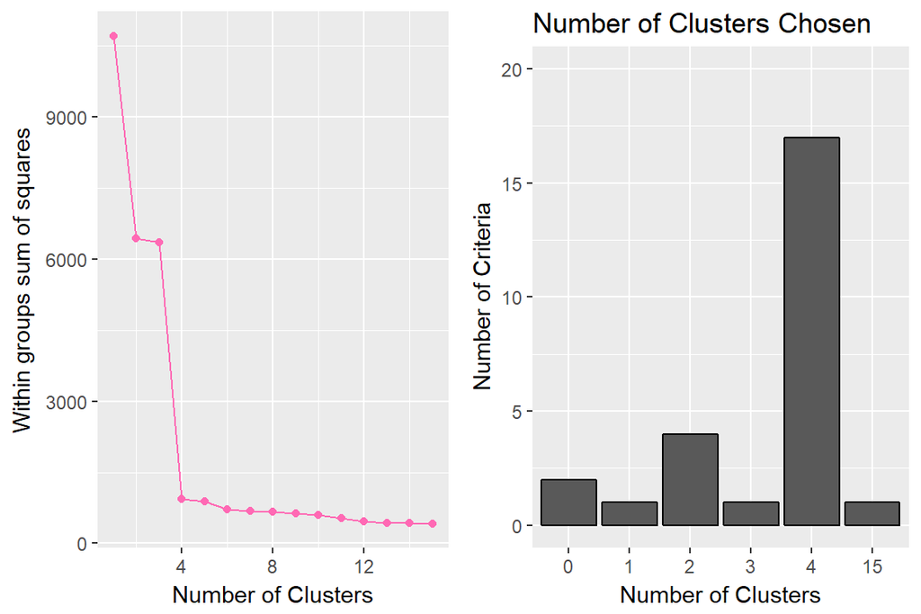

  ```r
  # 데이터 표준화
  hra_left <- hra_raw %>%
      filter(left == 1) %>%
      select(satisfaction_level, last_evaluation, average_montly_hours) %>%
      mutate(satisfaction_level_std = scale(satisfaction_level),
             last_evaluation_std = scale(last_evaluation),
             average_montly_hours_std = scale(average_montly_hours))

  # 클러스터링 용 데이터만 추출
  hra_left_cl_dat <- hra_left %>%
      select(ends_with("_std"))

  ## kmeans 알고리즘

  # 적절한 군집 개수 정하기 ( 1. sum of square 사용, 2. NBClust 사용)
  # 군집 내 sum of square 사용
  wss <- (nrow(hra_left_cl_dat)-1)*sum(apply(hra_left_cl_dat, 2, var))
  for(i in 2:15){
      set.seed(1)
      wss[i] <- sum(kmeans(hra_left_cl_dat, centers=i)$withinss)
  }

  wss_df <- data.frame(x = 1:15, wss)

  wss_plot <- wss_df %>%
      ggplot(aes(x = 1:15, y = wss)) +
      geom_point(color = "hotpink") +
      geom_line(color = "hotpink") +
      labs(x = "Number of Clusters", y = "Within groups sum of squares")

  # NbClust 사용
  library(NbClust)

  # 수행 시간이 오래 걸림, 결과가 있으면 불러오기
  file_nc <- "model/nc_seed_1.rds"
  if(file.exists(file_nc)){
      nc <- readRDS(file_nc)
  } else {
      nc <- NbClust(hra_left_cl_dat, min.nc=2, max.nc=15, method="kmeans")
      saveRDS(nc, file="model/nc_seed_1.rds")
  }

  # 군집 수 그래프 작성
  best_nc <- nc$Best.nc[1,]
  nbcluster_plot <- data.frame(name = names(best_nc), best_nc) %>%
      as_tibble() %>%
      group_by(best_nc) %>%
      summarise(cnt = n()) %>%
      ggplot(aes(x = factor(best_nc), y = cnt)) +
      geom_bar(stat = "identity", colour = "black") +
      scale_y_continuous(labels = comma, limits = c(0, 20)) +
      labs(x = "Number of Clusters", y = "Number of Criteria", title = "Number of Clusters Chosen")

  grid.arrange(wss_plot, nbcluster_plot, ncol = 2)
  ```

  - 퇴사자 클러스터링: 클러스터 해석
    - 클러스터 1: 만족도는 약간 낮고 평가가 낮고 월평균 근무시간이 적은 그룹 >> 적당히 일하는 사원
    - 클러스터 2: 만족도가 매우 낮고 평가가 높고 월평균 근무시간이 많은 그룹 >> 불만 많은 우수 사원
    - 클러스터 3: 만족도는 약간 낮고 평가가 낮고 월평균 근무시간이 많은 그룹 >> 근무 대비 성과가 안나오는 사원
    - 클러스터 4: 만족도가 매우 높고 평가가 높고 월평균 근무시간이 많은 그룹 >> 우수 사원

  ```r
  # 클러스터링 실행
  set.seed(1)
  hra_left_cluster <- kmeans(hra_left_cl_dat, 4)

  # kmeans 클러스터링 결과 추가
  hra_left_with_cluster <- hra_left %>%
      mutate(cluster = hra_left_cluster$cluster)

  # kmeans 결과 확인
  hra_left_with_cluster %>%
      group_by(cluster) %>%
      summarise(cnt = n(),
                satisfaction_level_m = mean(satisfaction_level),
                last_evaluation_m = mean(last_evaluation),
                average_montly_hours_m = mean(average_montly_hours)) %>%
      slice(1:4) %>%
      kable(format = "html", caption = "K-means clustering 결과 표") %>%
      kable_styling(bootstrap_options = "striped", full_width = F, position = "left")
  ```

  K-means clustering 결과 표

  | cluster | cnt | satisfaction_level_m | last_evaluation_m | average_montly_hours_m |
  | --- | --- | --- | --- | --- |
  | 1 | 1593 | 0.409 | 0.518 | 144 |
  | 2 | 917 | 0.107 | 0.872 | 275 |
  | 3 | 102 | 0.468 | 0.585 | 255 |
  | 4 | 959 | 0.808 | 0.918 | 242 |

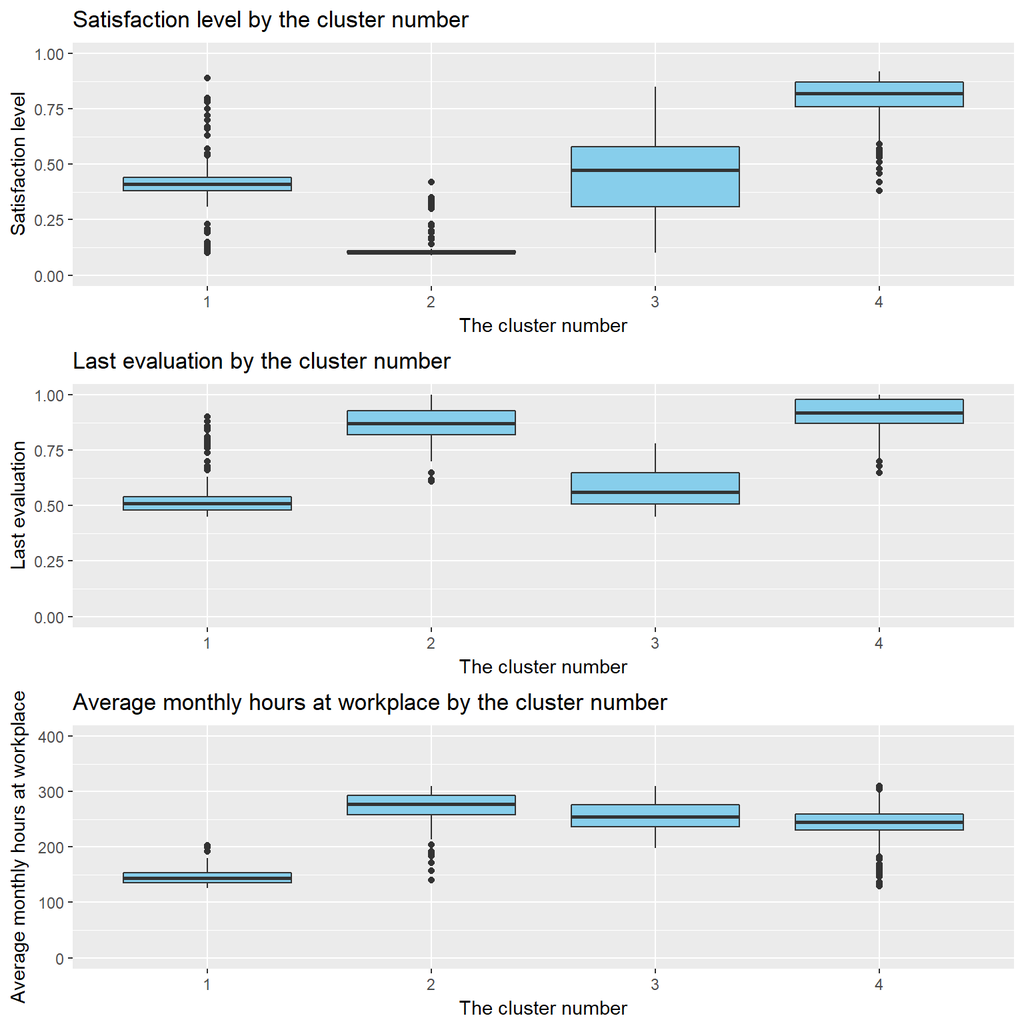

  ```r
  # 군집별 만족도
  cluster_plot_satisfaction_level <- hra_left_with_cluster %>%
      ggplot(aes(x = factor(cluster), y = satisfaction_level)) +
      geom_boxplot(fill = "skyblue") +
      scale_y_continuous(labels = comma, limits = c(0, 1)) +
      labs(x = "The cluster number", y = "Satisfaction level", title = "Satisfaction level by the cluster number")

  # 군집별 마지막 평가
  cluster_plot_last_evaluation <- hra_left_with_cluster %>%
      ggplot(aes(x = factor(cluster), y = last_evaluation)) +
      geom_boxplot(fill = "skyblue") +
      scale_y_continuous(labels = comma, limits = c(0, 1)) +
      labs(x = "The cluster number", y = "Last evaluation", title = "Last evaluation by the cluster number")

  # 군집별 평균 근무시간
  cluster_plot_average_montly_hours <- hra_left_with_cluster %>%
      ggplot(aes(x = factor(cluster), y = average_montly_hours)) +
      geom_boxplot(fill = "skyblue") +
      scale_y_continuous(labels = comma, limits = c(0, 400)) +
      labs(x = "The cluster number", y = "Average monthly hours at workplace", title = "Average monthly hours at workplace by the cluster number")

  grid.arrange(cluster_plot_satisfaction_level,
               cluster_plot_last_evaluation,
               cluster_plot_average_montly_hours, ncol = 1)
  ```

## 퇴사자 모델링

- 작성 중